# Individual Portion: Streaming Data

STT2860 F22 Project 03

Natara, Gracey, Evan

Wednesday, December 07, 2022 @ 07:35 PM

## Setup

### Packages Used

```r
library(tidyverse)
```

### Background of the Data

The datasets were downloaded from [Disney+ Movies and TV Shows | Kaggle](https://www.kaggle.com/datasets/shivamb/disney-movies-and-tv-shows) and [TV shows on Netflix, Prime Video, Hulu and Disney+ | Kaggle](https://www.kaggle.com/datasets/ruchi798/tv-shows-on-netflix-prime-video-hulu-and-disney). You can read about them there, including variable definitions, sources, when they were created, and other information. Load the two datasets and use `glimpse()` to explore their structures.

#### Disney+ Dataset

```r
disneydata <- readRDS("/home/students/dulaneynl/STT2860/git_repo/STT2860F22project3/data/disneypluscontent.rds")
disneydata
```

```
# A tibble: 1,446 × 13
   show_id type    title    direc…¹ cast  country date_…² relea…³ rating durat…⁴
   <chr>   <chr>   <chr>    <chr>   <chr> <chr>   <chr>     <dbl> <fct>  <chr>
 1 s1      Movie   Duck th… Alonso… Chri… <NA>    26-Nov…    2016 TV-G   23
 2 s2      Movie   Ernest … John C… Jim … <NA>    26-Nov…    1988 PG     91
 3 s3      Movie   Ice Age… Karen … Raym… United… 26-Nov…    2011 TV-G   23
 4 s4      Movie   The Que… Hamish… Darr… <NA>    26-Nov…    2021 TV-PG  41
 5 s6      Movie   Becomin… Liz Ga… Jacq… United… 24-Nov…    2021 PG-13  94
 6 s7      TV Show Hawkeye  <NA>    Jere… <NA>    24-Nov…    2021 TV-14  1
 7 s8      TV Show Port Pr… <NA>    Gary… United… 24-Nov…    2015 TV-14  2
 8 s9      TV Show Secrets… <NA>    Dr. … United… 24-Nov…    2019 TV-PG  2
 9 s10     Movie   A Muppe… Kirk R… Stev… United… 19-Nov…    2008 G      45
10 s11     Movie   Adventu… John G… Don … <NA>    19-Nov…    2020 TV-PG  59
# … with 1,436 more rows, 3 more variables: duration_unit <chr>,
#   listed_in <chr>, description <chr>, and abbreviated variable names
#   ¹director, ²date_added, ³release_year, ⁴duration
```

#### Streaming Dataset

```r
streamingdata <- readRDS("/home/students/dulaneynl/STT2860/git_repo/STT2860F22project3/data/streamingcontent.rds")
```

## Analyses

### Create the Analysis Datasets

#### Disney+ Dataset

Use `select()` to delete the variables `director`, `cast`, `country`, `listed in`, and `description` from the dataset.

```r
  new_disney_data <- select(disneydata, -director, -cast, -country, -listed_in, -description)
  new_disney_data
```

```
# A tibble: 1,446 × 8
   show_id type    title                  date_…¹ relea…² rating durat…³ durat…⁴
   <chr>   <chr>   <chr>                  <chr>     <dbl> <fct>  <chr>   <chr>
 1 s1      Movie   Duck the Halls: A Mic… 26-Nov…    2016 TV-G   23      min
 2 s2      Movie   Ernest Saves Christmas 26-Nov…    1988 PG     91      min
 3 s3      Movie   Ice Age: A Mammoth Ch… 26-Nov…    2011 TV-G   23      min
 4 s4      Movie   The Queen Family Sing… 26-Nov…    2021 TV-PG  41      min
 5 s6      Movie   Becoming Cousteau      24-Nov…    2021 PG-13  94      min
 6 s7      TV Show Hawkeye                24-Nov…    2021 TV-14  1       Seasons
 7 s8      TV Show Port Protection Alaska 24-Nov…    2015 TV-14  2       Seasons
 8 s9      TV Show Secrets of the Zoo: T… 24-Nov…    2019 TV-PG  2       Seasons
 9 s10     Movie   A Muppets Christmas: … 19-Nov…    2008 G      45      min
10 s11     Movie   Adventure Thru the Wa… 19-Nov…    2020 TV-PG  59      min
# … with 1,436 more rows, and abbreviated variable names ¹date_added,
#   ²release_year, ³duration, ⁴duration_unit
```

#### Streaming Dataset

I used a function called `pivot_longer()` on the downloaded data to change the shape of the dataset. You will need to do additional necessary editing on the dataset before you analyze it.

- Use `filter()` to remove any row where `YesNo` is `0` (a `0` means it is *not* on the service).
- Use the `separate()` function to split `IMDb`. Separate the show rating from the max rating of `10`.
- Use the `separate()` function to split `RottenTomatoes`. Separate the show rating from the max rating of `100`.
- Use `mutate()` to convert the shows’ IMDb and Rotten Tomatoes ratings into numerical variables instead of categorical.

```r
  new_streamingdata <- streamingdata %>%
  filter(YesNo == 1) %>%
  separate(col = IMDb , into = c("IMDBdrating", "IMBdmax"), sep = "/") %>%
  separate(col = RottenTomatoes, into = c("RTrating", "RTmax"), sep = "/")

new_streamingdata
```

```
# A tibble: 5,774 × 10
      ID Title            Year Age   IMDBd…¹ IMBdmax RTrat…² RTmax Service YesNo
   <dbl> <chr>           <dbl> <fct> <chr>   <chr>   <chr>   <chr> <chr>   <dbl>
 1     1 Breaking Bad     2008 18+   9.4     10      100     100   Netflix     1
 2     2 Stranger Things  2016 16+   8.7     10      96      100   Netflix     1
 3     3 Attack on Titan  2013 18+   9.0     10      95      100   Netflix     1
 4     3 Attack on Titan  2013 18+   9.0     10      95      100   Hulu        1
 5     4 Better Call Sa…  2015 18+   8.8     10      94      100   Netflix     1
 6     5 Dark             2017 16+   8.8     10      93      100   Netflix     1
 7     6 Avatar: The La…  2005 7+    9.3     10      93      100   Netflix     1
 8     6 Avatar: The La…  2005 7+    9.3     10      93      100   Prime …     1
 9     7 Peaky Blinders   2013 18+   8.8     10      93      100   Netflix     1
10     8 The Walking De…  2010 18+   8.2     10      93      100   Netflix     1
# … with 5,764 more rows, and abbreviated variable names ¹IMDBdrating,
#   ²RTrating
```

### Visualization 1: Release Year

**These plots use the Disney+ Dataset.**

A frequency polygon (`geom_freqpoly()`) is an alternative to a histogram. Rather than displaying bars, it connects the midpoints of a histogram’s bars with line segments. Create a frequency polygon for the year in which Disney+ content was released. Add an appropriate title and axis labels. Use other formatting as you choose to enhance effectiveness/appearance.

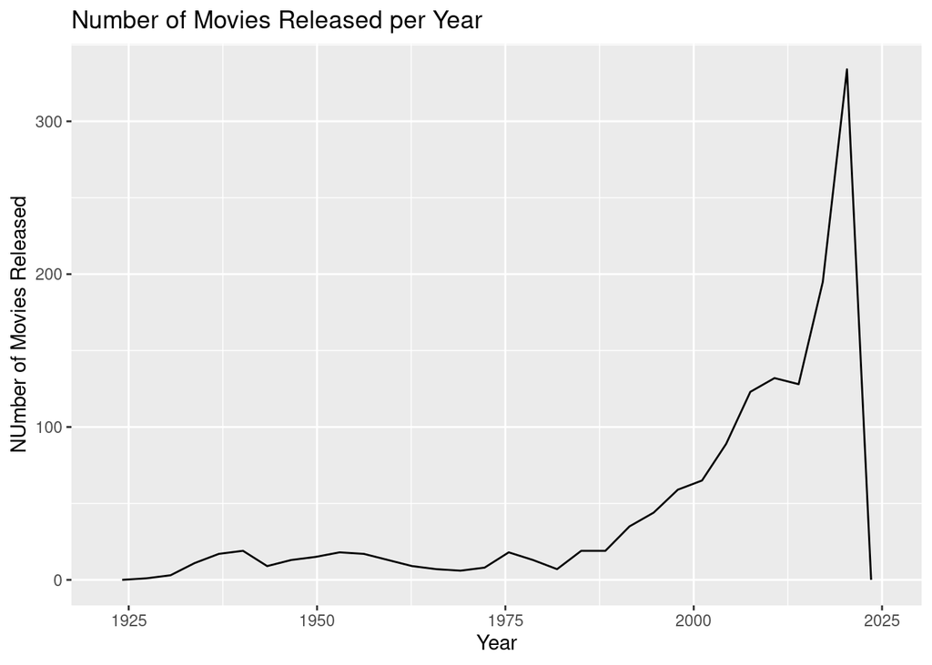

```r
ggplot(disneydata, aes(x = release_year)) +
  geom_freqpoly() +
  labs(x = "Year", y = "NUmber of Movies Released", title = "Number of Movies Released per Year")
```

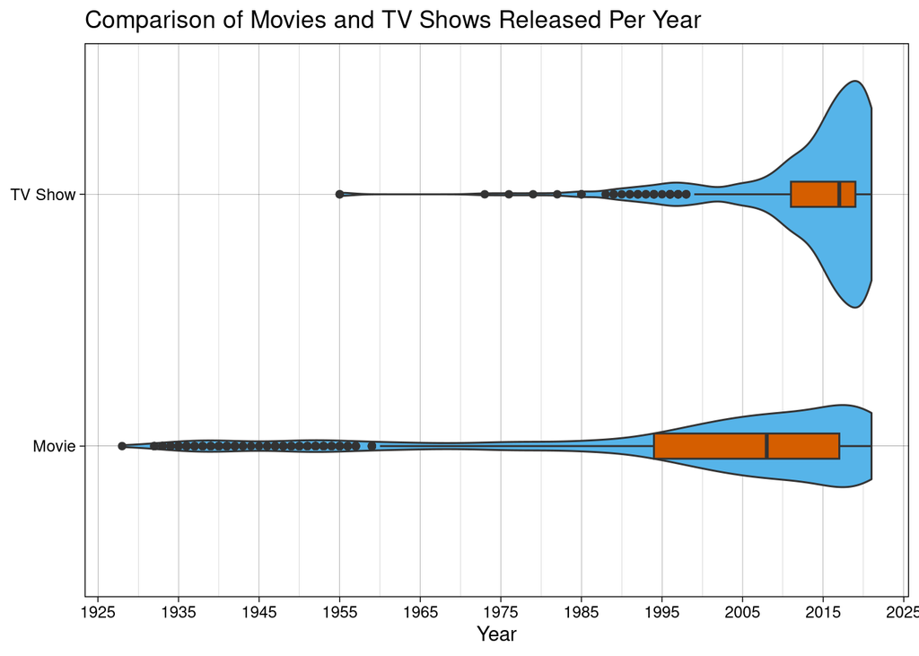

```r
ggplot(new_disney_data, aes(y = type, x = release_year)) +
geom_violin(fill = "#56B4E9") +
 geom_boxplot(fill = "#D55E00", width = .1) +
 scale_x_continuous(breaks = seq(1925,2025, by = 10)) +
 labs(title = "Comparison of Movies and TV Shows Released Per Year", x = "Year") +
 theme_linedraw() +
 theme(axis.title.y = element_blank())
```

### Visualization 2: Program Type

**This plot uses the Disney+ Dataset.**

Create a waffle plot (which you learned in DataCamp: [Visualization Best Practices in R](https://app.datacamp.com/learn/courses/visualization-best-practices-in-r)) to display the distribution of program `type` on Disney+.

- Give the plot the title “Streaming Content on Disney+”.
- Change the colors of the squares to something other than the defaults.
- Use an x-axis label to indicate roughly how many programs each square represents.

Hint: Use `round(100 * prop.table(table(DATASETNAME$VARIABLENAME)))` to create the “case_counts” data for the waffle plot. Swap out the capital letter placeholders in the instructions for the correct dataset name and variable name.

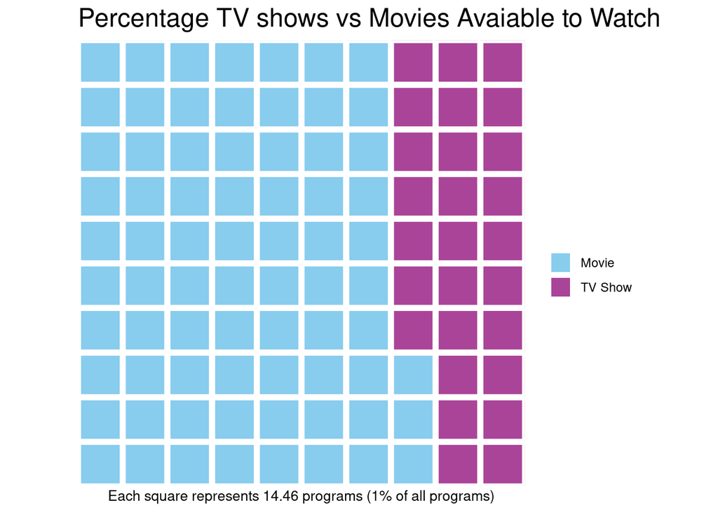

```r
library(waffle)
case_counts <- round(100 * prop.table(table(new_disney_data$type)))
waffle(case_counts, xlab = "Each square represents 14.46 programs (1% of all programs)", title = "Percentage TV shows vs Movies Avaiable to Watch",
  colors = c("#88ccEE", "#AA4499") )
```

### Visualization 3: Choose a Plot!

**This plot uses the Disney+ Dataset.**

Create one other plot of your choice from the Disney+ Dataset to explore a question of interest. You are welcome to perform additional manipulations on the data, if needed. Add an appropriate title and axis labels, as well as any other necessary formatting.

```r
new_disney_data
```

```
# A tibble: 1,446 × 8
   show_id type    title                  date_…¹ relea…² rating durat…³ durat…⁴
   <chr>   <chr>   <chr>                  <chr>     <dbl> <fct>  <chr>   <chr>
 1 s1      Movie   Duck the Halls: A Mic… 26-Nov…    2016 TV-G   23      min
 2 s2      Movie   Ernest Saves Christmas 26-Nov…    1988 PG     91      min
 3 s3      Movie   Ice Age: A Mammoth Ch… 26-Nov…    2011 TV-G   23      min
 4 s4      Movie   The Queen Family Sing… 26-Nov…    2021 TV-PG  41      min
 5 s6      Movie   Becoming Cousteau      24-Nov…    2021 PG-13  94      min
 6 s7      TV Show Hawkeye                24-Nov…    2021 TV-14  1       Seasons
 7 s8      TV Show Port Protection Alaska 24-Nov…    2015 TV-14  2       Seasons
 8 s9      TV Show Secrets of the Zoo: T… 24-Nov…    2019 TV-PG  2       Seasons
 9 s10     Movie   A Muppets Christmas: … 19-Nov…    2008 G      45      min
10 s11     Movie   Adventure Thru the Wa… 19-Nov…    2020 TV-PG  59      min
# … with 1,436 more rows, and abbreviated variable names ¹date_added,
#   ²release_year, ³duration, ⁴duration_unit
```

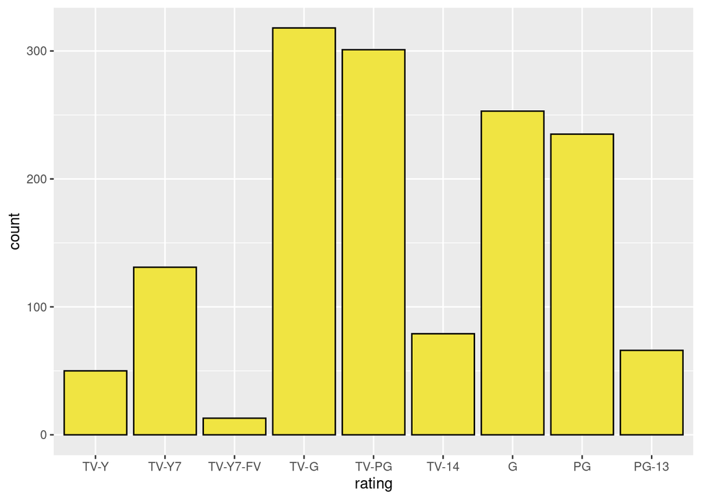

```r
ggplot(new_disney_data, aes(x = rating)) +
  geom_bar(fill = "#F0E442", color = "black")
```

### Visualization 4: Content Volume

**This plot uses the Streaming Dataset.**

Create a barplot to display how many shows are offered on each of the four streaming services. Choose appropriate colors, labels, themes, and/or and other types of formatting that you feel will enhance the meaning or visual appearance of the plot.

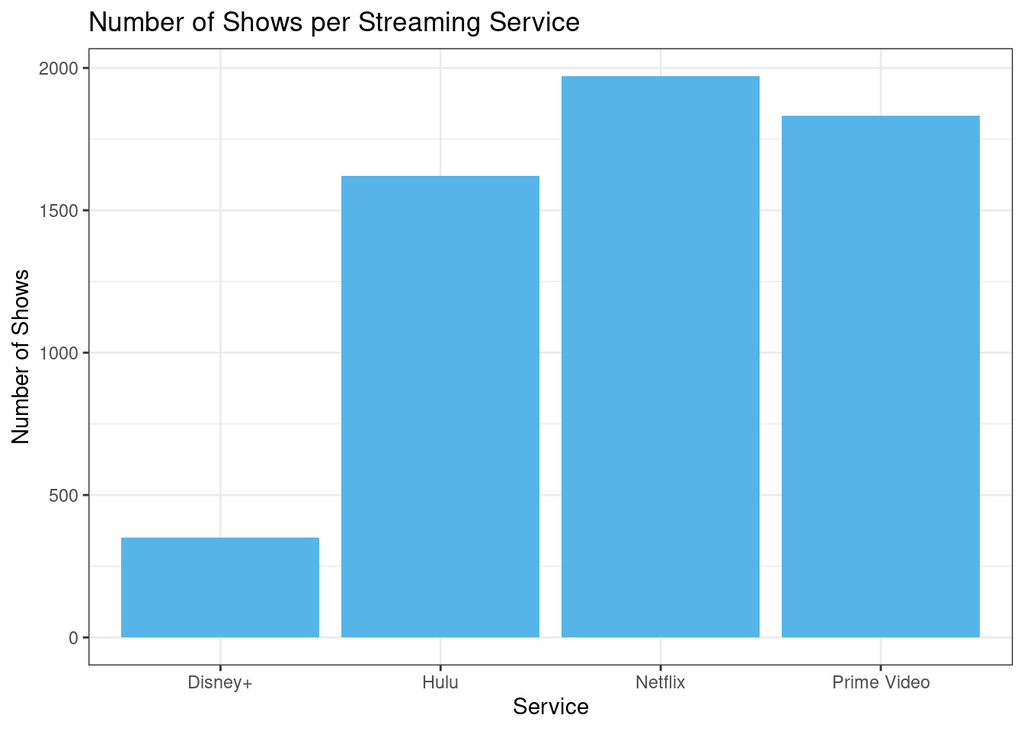

```r
ggplot(new_streamingdata, aes(x = Service)) +
  geom_bar(fill = "#56B4E9") +
  labs(title = "Number of Shows per Streaming Service", y = "Number of Shows") +
 theme_bw()
```

### Visualization 5: Choose a Plot!

**This plot uses the Streaming Dataset.**

Create one other plot of your choice from the Streaming Dataset to explore a question of interest. You are welcome to perform additional manipulations on the data, if needed. Add an appropriate title and axis labels, as well as any other necessary formatting.

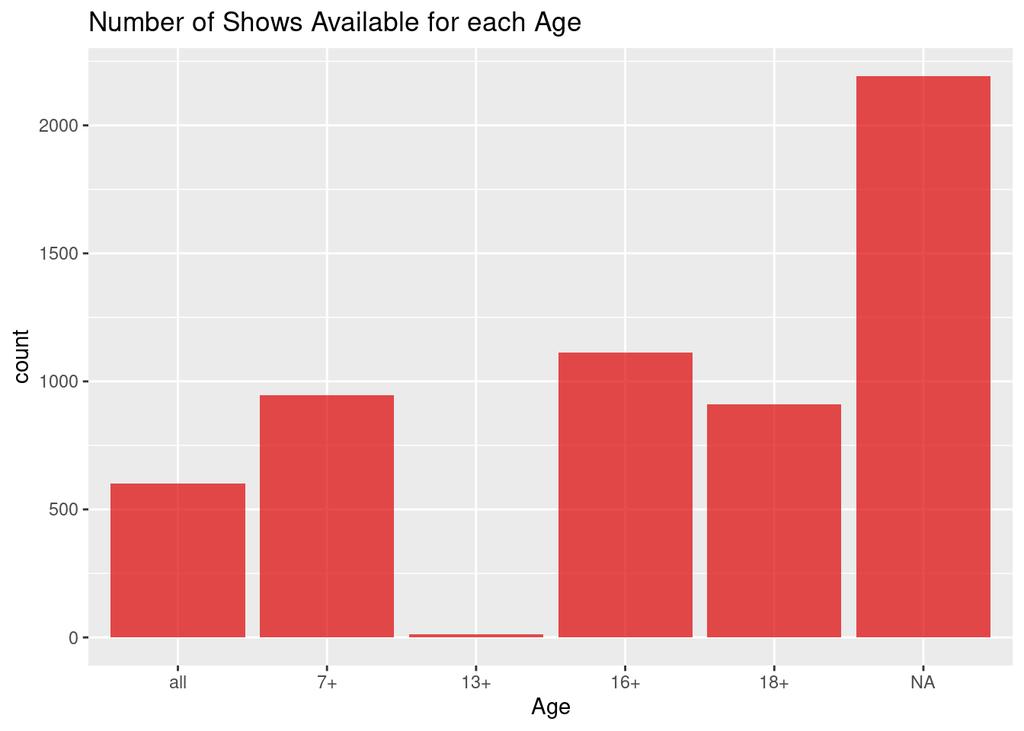

```r
ggplot(new_streamingdata, aes(x = Age)) +
  geom_bar(fill = "#DC0000B2") +
  labs(title = "Number of Shows Available for each Age")
```

```r
new_streamingdata
```

```
# A tibble: 5,774 × 10
      ID Title            Year Age   IMDBd…¹ IMBdmax RTrat…² RTmax Service YesNo
   <dbl> <chr>           <dbl> <fct> <chr>   <chr>   <chr>   <chr> <chr>   <dbl>
 1     1 Breaking Bad     2008 18+   9.4     10      100     100   Netflix     1
 2     2 Stranger Things  2016 16+   8.7     10      96      100   Netflix     1
 3     3 Attack on Titan  2013 18+   9.0     10      95      100   Netflix     1
 4     3 Attack on Titan  2013 18+   9.0     10      95      100   Hulu        1
 5     4 Better Call Sa…  2015 18+   8.8     10      94      100   Netflix     1
 6     5 Dark             2017 16+   8.8     10      93      100   Netflix     1
 7     6 Avatar: The La…  2005 7+    9.3     10      93      100   Netflix     1
 8     6 Avatar: The La…  2005 7+    9.3     10      93      100   Prime …     1
 9     7 Peaky Blinders   2013 18+   8.8     10      93      100   Netflix     1
10     8 The Walking De…  2010 18+   8.2     10      93      100   Netflix     1
# … with 5,764 more rows, and abbreviated variable names ¹IMDBdrating,
#   ²RTrating
```

## Questions

**Question 1:** Based on your plots, make five informational statements or comparisons regarding the Disney+ streaming service.

**Question 2:** What other data would you like to have, or which existing variables would you like to see transformed, if you were going to do further explorations or visualizations? Give at least two examples.

What does the NA mean any the streaming data? We would like to see the data for that specific range of shows available. We would like to see further exploration in how many users watch each show and movie across the different streaming platforms.

**Question 3:** Explain the rationale behind the choices you made with regard to plot type, formatting, and so on, when you created Visualizations 3 and 5. Walk me through your process. What motivated your decisions?

We chose a barplot for Visualization 3 because we wanted to explore what ratings had the most TV shows and Movies. The bar graph was best because it clearly conveys the count of TV shows and Movies. We chose a barplot for Visualization 5 because we wanted to see the number of shows availabe for each age demographic.